# Thesis - preliminary data

Lukas Hejtmanek

Monday, November 17, 2014

Let’s do some data readings

```r
setwd("U:/Vyzkum/Diplomka/DiplomkaGit")
library(ggplot2)
library(data.table)
library(plyr)
```

We will look at the first version of the experiment first

```r
newTable=fread("newTableVer3.txt",sep=";",header=T,autostart=1)
```

I have already loaded and prepared all the necessary data. I will elaborate on this process later. No subjects are crossed out at this point. It takes about 2-5 minutes on a moderately strong PC (i5-4440, 8GB RAM)

Demographics:

We have several tables available for us to use:

- log_table : contains all the data from the experiment
- test_table : contains important data from the point where the subject gives his/her answer
- newTable : useful aggregation of data from both the log table and test table. Contains information about switching, orientation points, angular distance traveled etc.
- useTable: small concise table to use in ggplot. newTable has 6012 rows with about 63 fifty columns, therefore 378756 cells in total. It’s not generally a good idea to load the whole object into ggplot. Use table has only data which has been defined as either correct or inconclusive

The tables include two distinct groups:

- Those with the posiibility of same goals occuring one after another in F2, F4 and F5
- Those who never had two same goals in a row

TRUE singnifies that same letters could occur after each other.

Let’s have a look at the percentages of correct answers.

Data for the F3 : continuous free turning

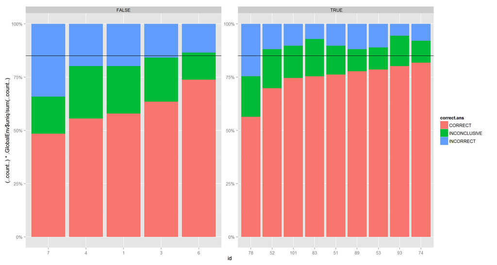

Data for the F4 : free turning with orienting to a landmark

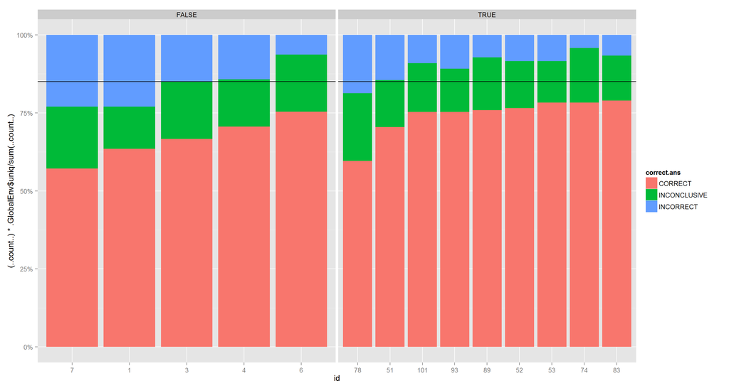

Data for the F5 : 2s delay before giving the goal.

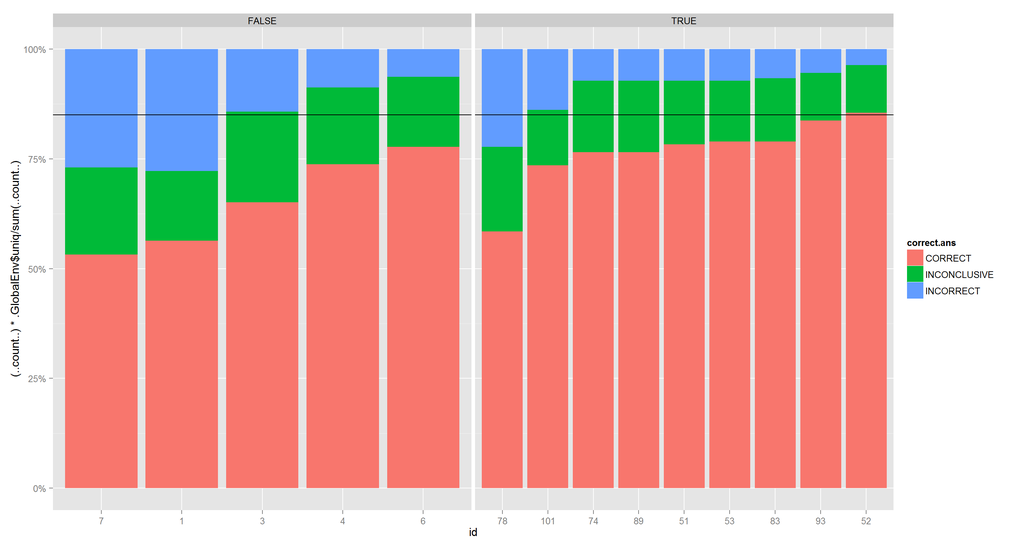

We can see that quite a lot of subjects had problems with the task. Total of 5 subjects gave more than 15 percent of wrong answers in the F3, 4 in the F4 and 3 in F5. Out of those 4 gave more then 15 percent of wrong answers in two test phases and 3 in all three.

Nevertheless, here are some tables:

General plot for all the correct answers from all the subjects:

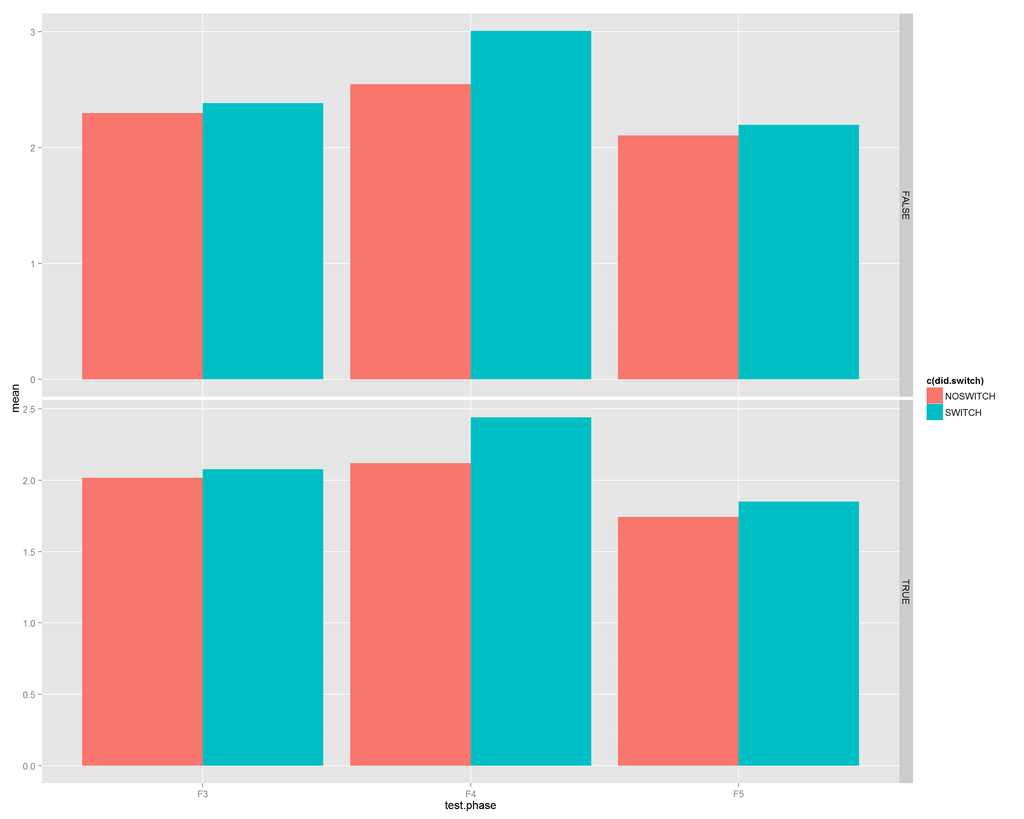

General plot for all the correct answers from subject who had less then 15% errors in the phase::

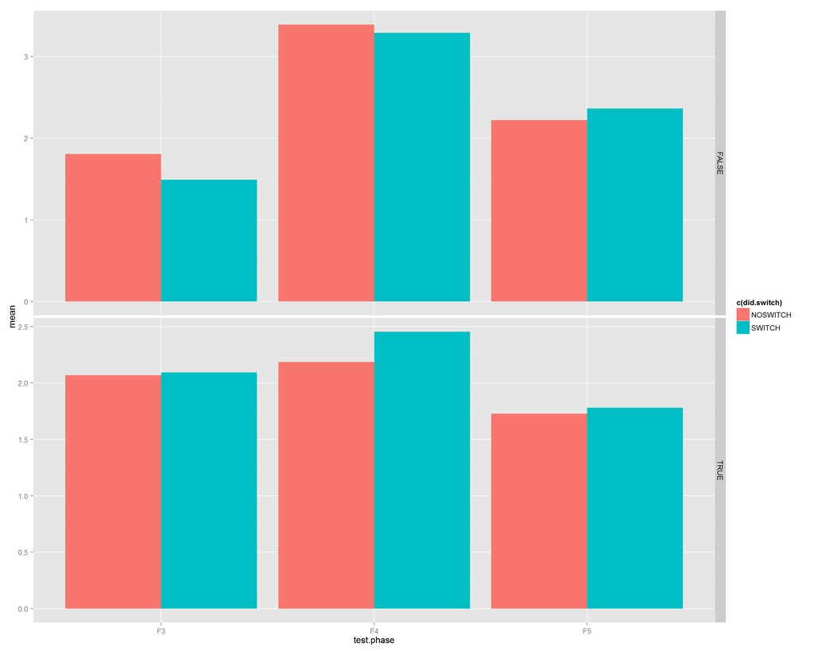

General plot for all the correct answers from subject who had less then 15% errors in the phase:

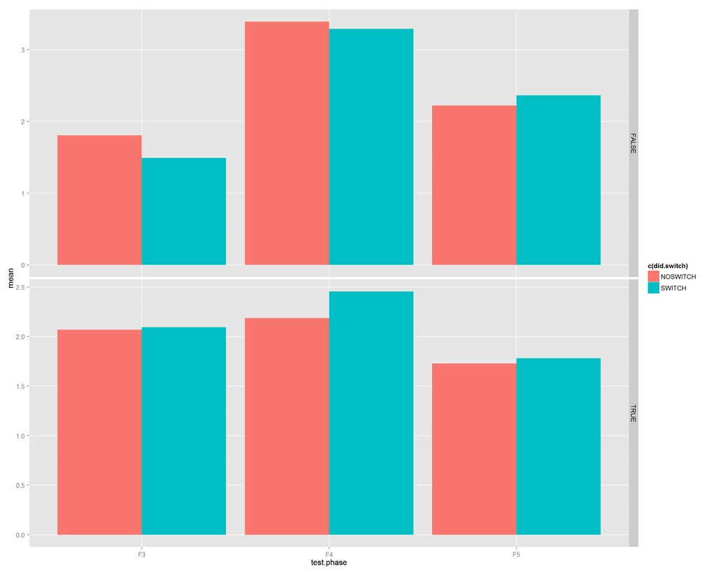

Similar data like in the last example, but only reaction times under 3s are evealuated

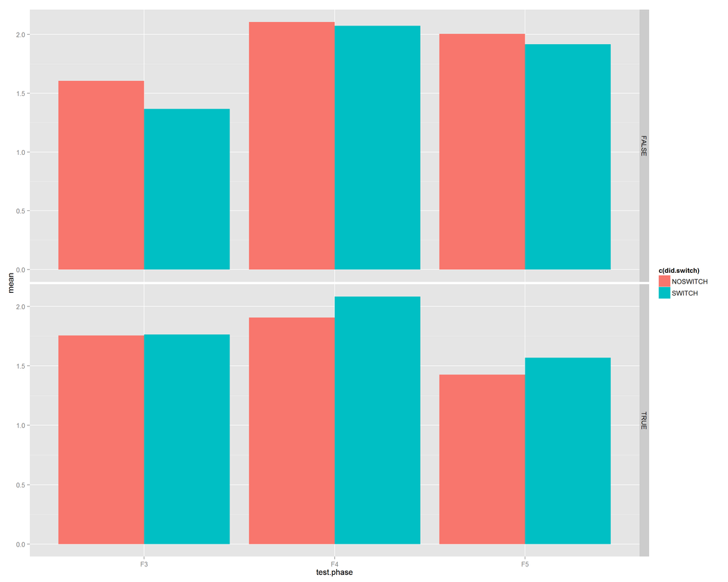

DAta split based on the landmark provided: Graphs for Same Letters == T:

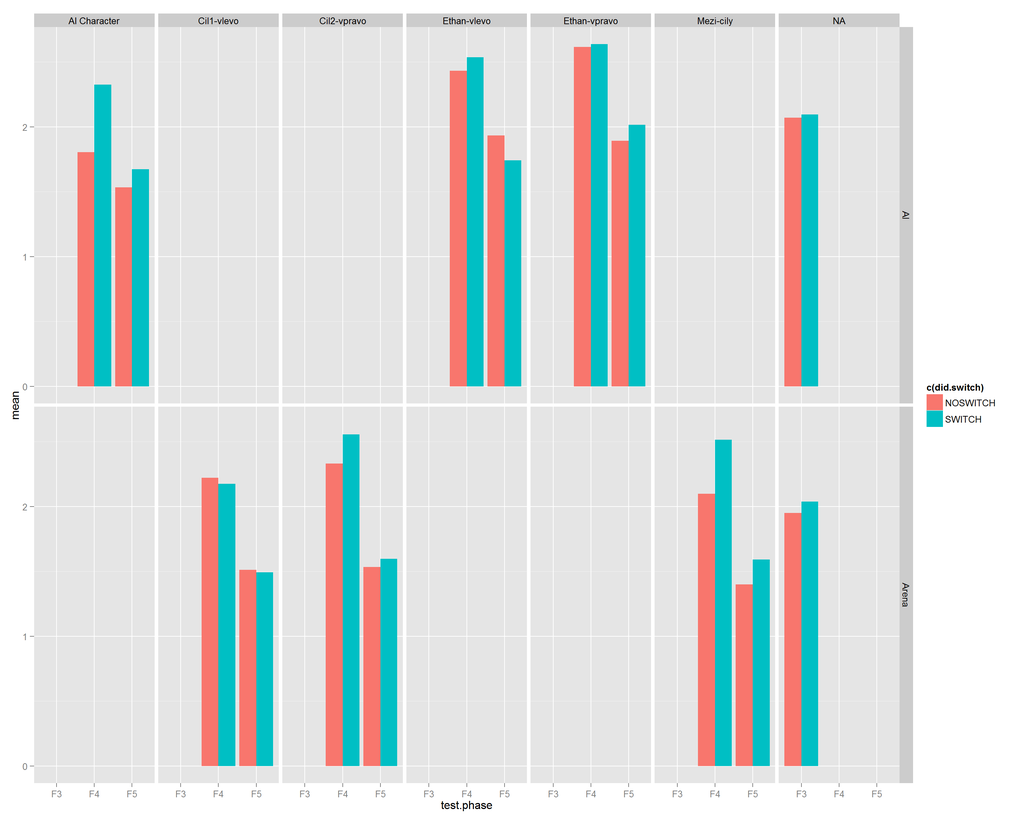

Graphs for Same Letters == F:

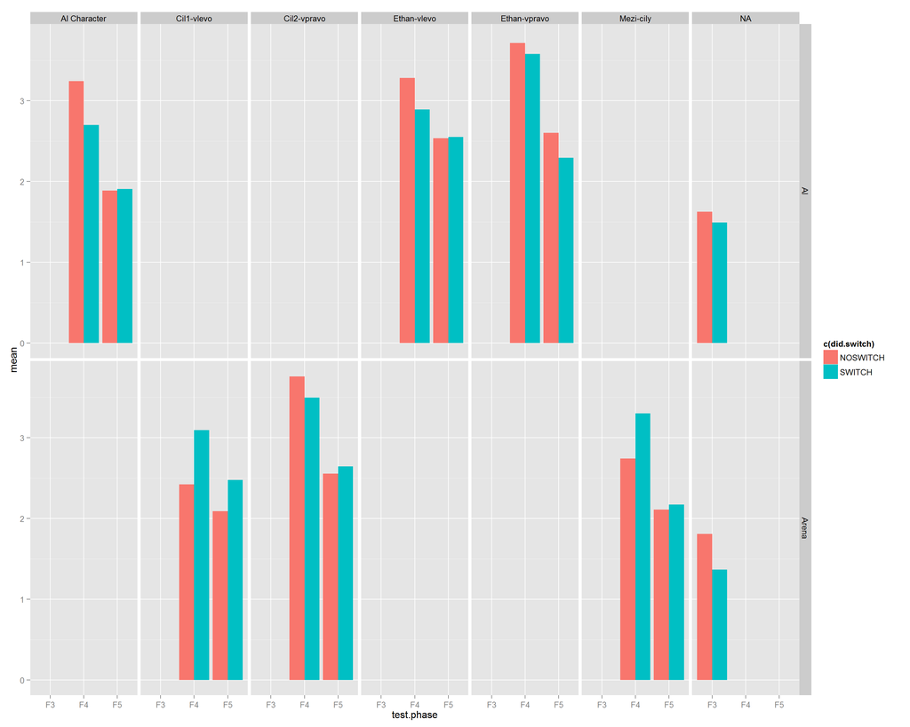

Now the experimentation begins.

There are several distances we can use for control:

- distance1: this is an angular distance between a goal and player rotation at the time when the task is given. Distance1 has values between -180 to 180 degrees. Negative values are for distances 0-180 degrees to the left, positive 0-180 degrees to the right.
- distance2: same as above but with the difference that the target position is computed at the time of subject’s answer. Distance2 has also values between -180 to 180 degrees. Negative values are for distances 0-180 degrees to the left, positive 0-180 degrees to the right.
- cumsumAngAbs: absolute value of angular movement of the player up to the point when the answer is given.
- cumsumLeftAng: absolute value of left angular movement
- cumsumRightAng: absolute value of right angular movement

WE can control the time subject needs to answer with the movement he needs to make. Simplest form is to presume linear movement of the subjects answer and then simply controll the reaction time by it:

Graphs for Same Letters == F, controlled by distance1:

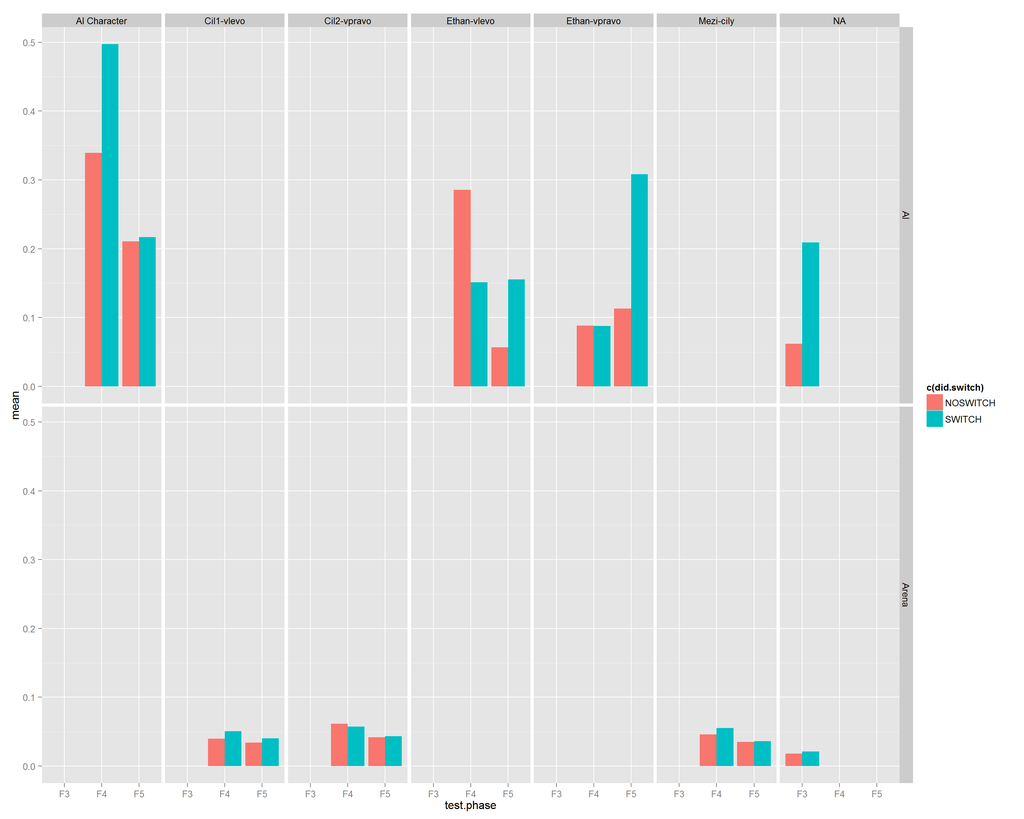

Graphs for Same Letters == F, controlled by distance2:

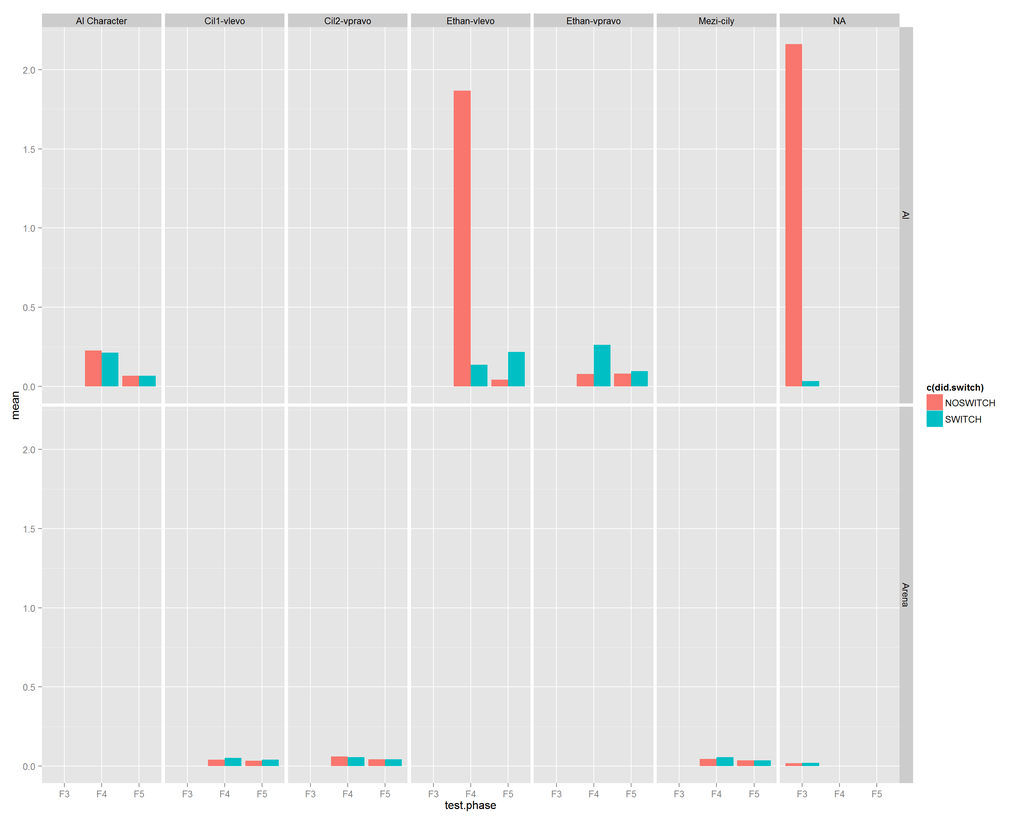

Graphs for Same Letters == T, controlled by distance1:

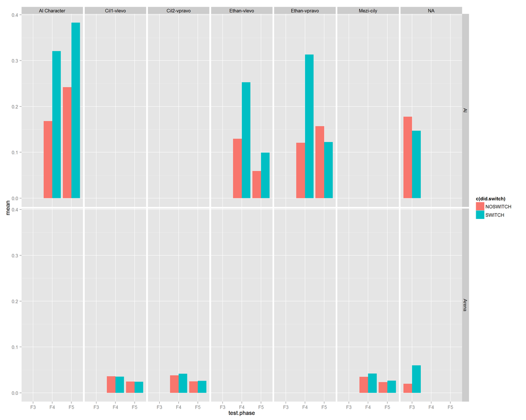

Graphs for Same Letters == T, controlled by distance2:

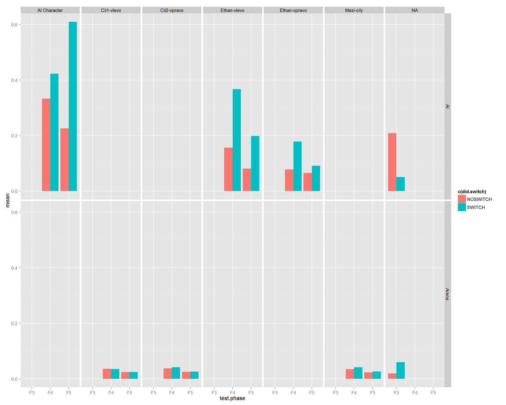

Graphs for Same Letters == F, controlled by cumsumAngAbs:

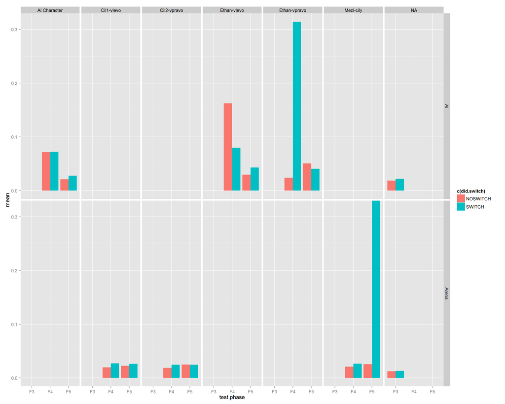

Graphs for Same Letters == T, controlled by cumsumAngAbs:

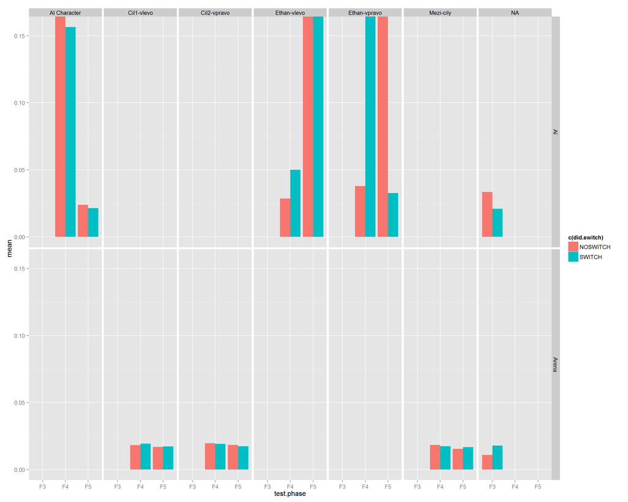